# Introduction to TPP2D for 2D-TPP analysis

Nils Kurzawa

2/25/2019

#### Package

TPP2D 0.1.0

# 1 Abstract

Thermal proteome profiling (TPP) (Savitski et al., 2014, Franken et al. (2015)) is an unbiased mass spectrometry-based method to assess protein-ligand interactions. It works by employing the cellular thermal shift assay (CETSA) (Molina et al., 2013) on a proteome-wide scale which in brief monitors the profiles of proteins in cells over a temperature gradient and tries to detect shifts induced by ligand-protein interactions in a treatment versus a control sample. 2D-TPP represents a refined version of the assay (Becher et al., 2016) which uses a concentration gradient of the ligand of interest over a temperature gradient. This package aims to analyze data retrieved from 2D-TPP experiments by a functional analysis approach.

# 2 General information

This package aims at providing an analysis tool for datasets obtained with the 2D-TPP assay. Please note that methods for analyzing convential TPP datasets (e.g. single dose, melting curve approach) can be found at: https://bioconductor.org/packages/release/bioc/html/TPP.html and https://git.embl.de/childs/TPP-data-analysis/blob/master/NPARC_paper/reports/NPARC_workflow.Rmd .

This vignette is not aimed to represent an in-depth introduction to thermal proteome profiling, please refer to other sources for this purpose:  
- Original TPP paper: http://science.sciencemag.org/content/346/6205/1255784  
- 2D-TPP paper: https://www.nature.com/articles/nchembio.2185  
- review article: https://proteomesci.biomedcentral.com/articles/10.1186/s12953-017-0122-4

# 3 Installation

The TPP2D package is in the process of being submitted to Bioconductor. So long the development version on github can be installed as follows:

```r
require(devtools)
devtools::install_github("nkurzaw/TPP2D")
```

# 4 Introduction

```r
library(dplyr)
library(TPP2D)
```

After having loaded `dplyr` the `TPP2D` package itself we start by loading example dataset which is supplied with the package. We therefor use the `import2dDataset` function.  
For this puporse we need to supply a config table that essentially describes which experimental conditions the different TMT labels used correspond to and supplies paths to the raw data files (note: since this example dataset is included in the package it does not contain a “Path” column, this is however mandatory if the data should be read in from external raw files).

```r
data("config_tab")
data("raw_dat_list")

config_tab
```

```
##     Compound Experiment Temperature 126 127L 127H 128L 128H 129L 129H 130L
## 1  Compound1       exp1        37.0   0  0.5    2   10   40    -    -    -
## 2  Compound1       exp1        37.8   -    -    -    -    -    0  0.5    2
## 3  Compound1       exp2        40.4   0  0.5    2   10   40    -    -    -
## 4  Compound1       exp2        44.0   -    -    -    -    -    0  0.5    2
## 5  Compound1       exp3        46.9   0  0.5    2   10   40    -    -    -
## 6  Compound1       exp3        49.8   -    -    -    -    -    0  0.5    2
## 7  Compound1       exp4        52.9   0  0.5    2   10   40    -    -    -
## 8  Compound1       exp4        55.5   -    -    -    -    -    0  0.5    2
## 9  Compound1       exp5        58.6   0  0.5    2   10   40    -    -    -
## 10 Compound1       exp5        62.0   -    -    -    -    -    0  0.5    2
## 11 Compound1       exp6        65.4   0  0.5    2   10   40    -    -    -
## 12 Compound1       exp6        66.3   -    -    -    -    -    0  0.5    2
##    130H 131L RefCol
## 1     -    -    126
## 2    10   40   129L
## 3     -    -    126
## 4    10   40   129L
## 5     -    -    126
## 6    10   40   129L
## 7     -    -    126
## 8    10   40   129L
## 9     -    -    126
## 10   10   40   129L
## 11    -    -    126
## 12   10   40   129L
```

We then call the import function (note: we here supply a list of data frames for the “data” argument, replacing the raw data files that would be normally specified in the above mentioned column of the config table. If this is supplied the argument “data” can simply be ignored):

```r
import_df <- import2dDataset(configTable = config_tab,
                             data = raw_dat_list,
                             idVar = "protein_id",
                             intensityStr = "signal_sum_",
                             fcStr = "rel_fc_",
                             nonZeroCols = "qusm",
                             geneNameVar = "gene_name",
                             addCol = NULL,
                             qualColName = "qupm",
                             naStrs = c("NA", "n/d", "NaN"),
                             concFactor = 1e6,
                             medianNormalizeFC = TRUE,
                             filterContaminants = TRUE)
```

```
## The following valid label columns were detected:
## 126, 127L, 127H, 128L, 128H, 129L, 129H, 130L, 130H, 131L.
```

```
## Importing 2D-TPP dataset: exp1
```

```
## Removing duplicate identifiers using quality column 'qupm'...
```

```
## 20 out of 20 rows kept for further analysis.
```

```
## Importing 2D-TPP dataset: exp1
```

```
## Removing duplicate identifiers using quality column 'qupm'...
```

```
## 20 out of 20 rows kept for further analysis.
```

```
## Importing 2D-TPP dataset: exp2
```

```
## Removing duplicate identifiers using quality column 'qupm'...
```

```
## 20 out of 20 rows kept for further analysis.
```

```
## Importing 2D-TPP dataset: exp2
```

```
## Removing duplicate identifiers using quality column 'qupm'...
```

```
## 20 out of 20 rows kept for further analysis.
```

```
## Importing 2D-TPP dataset: exp3
```

```
## Removing duplicate identifiers using quality column 'qupm'...
```

```
## 15 out of 15 rows kept for further analysis.
```

```
## Importing 2D-TPP dataset: exp3
```

```
## Removing duplicate identifiers using quality column 'qupm'...
```

```
## 15 out of 15 rows kept for further analysis.
```

```
## Importing 2D-TPP dataset: exp4
```

```
## Removing duplicate identifiers using quality column 'qupm'...
```

```
## 14 out of 14 rows kept for further analysis.
```

```
## Importing 2D-TPP dataset: exp4
```

```
## Removing duplicate identifiers using quality column 'qupm'...
```

```
## 14 out of 14 rows kept for further analysis.
```

```
## Importing 2D-TPP dataset: exp5
```

```
## Removing duplicate identifiers using quality column 'qupm'...
```

```
## 9 out of 9 rows kept for further analysis.
```

```
## Importing 2D-TPP dataset: exp5
```

```
## Removing duplicate identifiers using quality column 'qupm'...
```

```
## 9 out of 9 rows kept for further analysis.
```

```
## Importing 2D-TPP dataset: exp6
```

```
## Removing duplicate identifiers using quality column 'qupm'...
```

```
## 4 out of 4 rows kept for further analysis.
```

```
## Importing 2D-TPP dataset: exp6
```

```
## Removing duplicate identifiers using quality column 'qupm'...
```

```
## 4 out of 4 rows kept for further analysis.
```

```
## Ratios were correctly computed!
```

```
## Median normalizing fold changes...
```

```r
recomp_sig_df <- recomputeSignalFromRatios(import_df)
```

Please refer to the help page of the function to retrieve in-depth description of the different arguments. Essentially the function needs to know the names or prefixes of the columns in the raw data files, that contain different informations like protein id or the raw or relative signal intensities measured for the different TMT labels.  
The imported synthetic dataset consists of 17 simulated protein 2D thermal profiles (protein1-17) and 3 spiked-in true positives (tp1-3). It represents a data frame with the columns:

| column | description | required |
| --- | --- | --- |
| representative | protein identifier | Yes |
| qupm | number of unique quantified peptides | No |
| qusm | number of unique spectra | No |
| clustername | gene name | Yes |
| temperature | temperature incubated at | Yes |
| experiment | experiment identifier | No |
| label | TMT label | No |
| RefCol | RefCol | No |
| conc | treatment concentration | No |
| raw_value | raw reporter ion intensity sum | No |
| raw_rel_value | raw relative fold change compared to vehicle condition at the same temperature | No |
| log_conc | log10 treatment concentration | Yes |
| rel_value | median normalized fold change | No |
| value | recomputed reporter ion intensity | No |
| log2_value | recomputed log2 reporter ion intensity | Yes |

Here the column “required” indicated which of these columns is neccessary for usage of the downstream functions.

We then begin our actual data analysis by fitting two competing models to each protein profile.

```r
competed_models <- competeModels(
  df = recomp_sig_df,
  optim_fun_h0 = TPP2D:::min_RSS_h0,
  optim_fun_h1 = TPP2D:::min_RSS_h1_slope_pEC50,
  optim_fun_h1_2 = NULL)
```

Then we create a null model using our dataset to be able to estimate the FDR for a given F statistic in the next step.

```r
set.seed(12, kind = "L'Ecuyer-CMRG")
null_model <- bootstrapNull(
  df = recomp_sig_df,
  optim_fun_h0 = TPP2D:::min_RSS_h0,
  optim_fun_h1 = TPP2D:::min_RSS_h1_slope_pEC50,
  optim_fun_h1_2 = NULL,
  ncores = 1, B = 2)
```

Please note that setting B = 2 is not enough to guarantee faithful FDR estimation, this has simply been set for fast demonstration purposes. We recommend to use at least B = 20 for applications in praxis.

To estimate the FDR for all given F statistics and retrieve all significant hits at a set FDR $\alpha$ we use the following functions:

```r
fdr_tab <- computeFdr(
  df_out = competed_models,
  df_null = null_model)

hits <- findHits(
  fdr_df = fdr_tab,
  alpha = 0.1)

hits %>% dplyr::select(clustername, nObs, F_statistic, fdr)
```

```
## # A tibble: 7 x 4
##   clustername  nObs F_statistic   fdr
##   <chr>       <int>       <dbl> <dbl>
## 1 tp1            20       78.8      0
## 2 tp2            30       53.9      0
## 3 tp3            50       28.2      0
## 4 protein16      40        1.62     0
## 5 protein10      50        2.61     0
## 6 protein1       20        1.23     0
## 7 protein15      50        2.15     0
```

Finally we can fit and plot proteins that have come up as significant in our analysis by using:

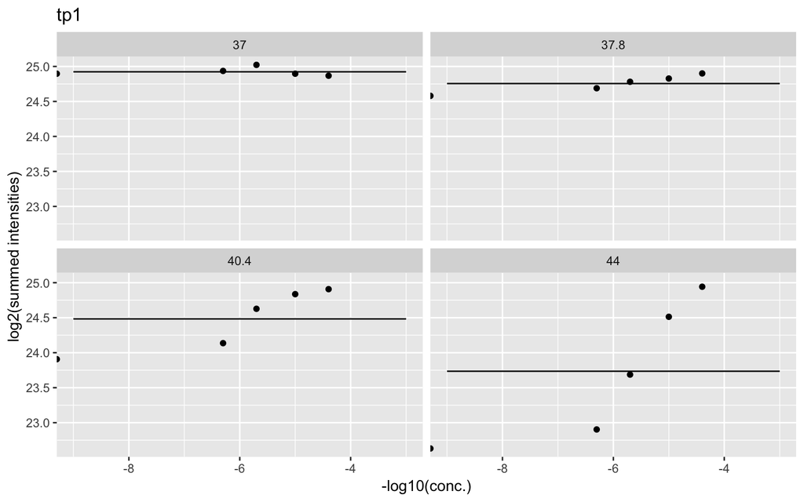

```r
plot2dTppFit(recomp_sig_df, "tp1")
```

or respectively for the H1 model:

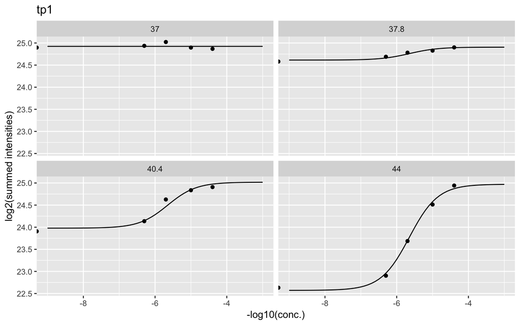

```r
plot2dTppFit(recomp_sig_df, "tp1", model_type = "H1", optim_fun = TPP2D:::min_RSS_h1)
```

# References

Becher, I., Werner, T., Doce, C., Zaal, E.A., Tögel, I., Khan, C.A., Rueger, A., Muelbaier, M., Salzer, E., Berkers, C.R., et al. (2016). Thermal profiling reveals phenylalanine hydroxylase as an off-target of panobinostat. Nature Chemical Biology *12*, 908–910.

Franken, H., Mathieson, T., Childs, D., Sweetman, G.M.A., Werner, T., Tögel, I., Doce, C., Gade, S., Bantscheff, M., Drewes, G., et al. (2015). Thermal proteome profiling for unbiased identification of direct and indirect drug targets using multiplexed quantitative mass spectrometry. Nature Protocols *10*, 1567–1593.

Molina, D.M., Jafari, R., Ignatushchenko, M., Seki, T., Larsson, E.A., Dan, C., Sreekumar, L., Cao, Y., and Nordlund, P. (2013). Monitoring Drug Target Engagement in Cells and Tissues Using the Cellular Thermal Shift Assay. Science *341*, 84–88.

Savitski, M.M., Reinhard, F.B.M., Franken, H., Werner, T., Savitski, M.F., Eberhard, D., Martinez Molina, D., Jafari, R., Dovega, R.B., Klaeger, S., et al. (2014). Tracking cancer drugs in living cells by thermal profiling of the proteome. Science *346*, 1255784.